# Super Mario Bros.

### *jap. スーパーマリオブラザーズ*

**Komputerowa gra platformowa wyprodukowana w 1985 roku przez Nintendo.Super Mario Bros., stworzona w dużej mierze przez Shigeru Miyamoto, odniosła sukces komercyjny, spowodowany jej sprzedażą wraz z konsolą Nintendo Entertainment System.**

[figure not shown]

#### Rozrywka

Głównym bohaterem Super Mario Bros., nad którym gracz przejmuje kontrolę, jest postać Mario. Jego młodszym bratem bliźniakiem, Luigim, kieruje wyłącznie drugi gracz w trybie gry wieloosobowej. Zadaniem obu bohaterów jest eksploracja krainy Mushroom Kingdom, przetrwanie w obliczu ataku sił głównego antagonisty Bowsera oraz ocalenie księżniczki Toadstool[7]. Gracz porusza się w kierunku prawej strony ekranu, aby dotrzeć do chorągiewki pojawiającej się na końcu każdego poziomu.

#### Bohaterowie

- Mario
- Luigi
- Toad
- Peach

[figure not shown]

#### Transformacje Mario

| Mario |  | Umiejętności |
| --- | --- | --- |
| Small Mario |  | najsłabszy; podstawowa wersja |
| Super Mario |  | może rozwalać bloki; wraca do małego Mario jak dotknie wroga |
| Fire Mario |  | rzuca kulami ognia |
| Invincible Mario |  | jest niezwyciężony; odporny na przeszkody; pokonuje wrogów bez skakania na nich |

#### Wrogowie

1. Groomba - Goomby mają tylko nogi. Wielu z Goomb to poddani Bowsera. Aby pokonać Goombę należy go po prostu rozdeptać.

[figure not shown]

2. Spiny - Spiny to czworonożny Koopa Troopa, który zadebiutował w Super Mario Bros. Najczęściej wyrzucają je Lakitu w nieskończonych ilościach, ale czasami pojawiają się, gdy nie ma ich w pobliżu.
3. Blooper - o ośmiornicopodobne stworzenia żyjące w wodzie. Są jednymi z najbardziej odpornych przeciwników niebędących bossami.

[figure not shown]

4. Cheep-Cheep - w Japonii nazywane Pukupuku (プクプク) są rybami posiadającymi skrzydła
5. Hammer Bro. - Są zielone, mają skorupę i zielony kask, ale rzucają młotkami, co uczyniło ich najtrudniejszymi do pokonania wrogami niebędącymi Bossem.
6. Lakitu - to Koopa z pilotką, który siedzi na chmurce. Wyrzuca Spiny, których ma nieskończoność.

ENJOY!: (http://pl.joy.land/super-mario-bros.html)

```r
dzien <- 24
miesiac <- (dzien * 30)
rok <- (dzien * 365)
IIrok <- ((miesiac - (8 * dzien) + (9 * miesiac)))
III_IVrok <- (2 * rok)
Vrok <- (6 * miesiac )
WYNIK <- (IIrok + III_IVrok + Vrok)
```

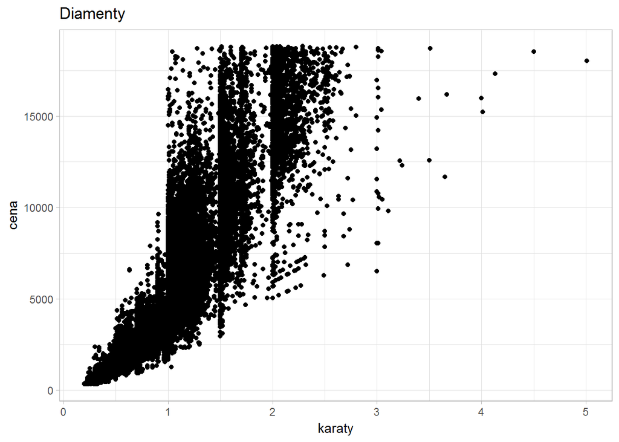

```r
library(tidyverse)
ggplot(data = diamonds) +
  geom_point(mapping = aes (x = carat, y = price)) +
  labs(title = "Diamenty", x = "karaty", y = "cena") +
  theme_light()
```

```r
library(tidyverse)
data(diamonds)
select(diamonds, cut)
```

```
## # A tibble: 53,940 x 1
##    cut
##    <ord>
##  1 Ideal
##  2 Premium
##  3 Good
##  4 Premium
##  5 Good
##  6 Very Good
##  7 Very Good
##  8 Very Good
##  9 Fair
## 10 Very Good
## # ... with 53,930 more rows
```